# Divers_analyses

# 2. Phéno par cluster

## 2.1 Flow on

```r
mod_clust <- aov(Flow_on ~ clust, data=data_ENI)
summary(mod_clust)
```

```
##               Df Sum Sq Mean Sq F value Pr(>F)
## clust          2    1.4  0.6875    3.33 0.0359 *
## Residuals   2407  496.9  0.2064
## ---
## Signif. codes:  0 '***' 0.001 '**' 0.01 '*' 0.05 '.' 0.1 ' ' 1
```

```r
pairwise.t.test(data_ENI$Flow_on, data_ENI$clust, p.adj = "bonferroni")
```

```
##
##  Pairwise comparisons using t tests with pooled SD
##
## data:  data_ENI$Flow_on and data_ENI$clust
##
##   1     2
## 2 0.906 -
## 3 0.052 0.289
##
## P value adjustment method: bonferroni
```

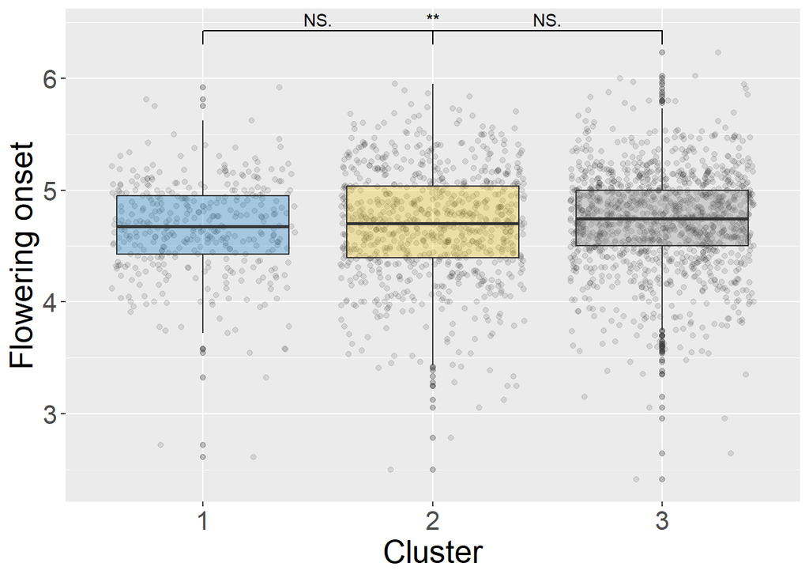

```r
ggplot(data= data_ENI) +
  aes(x= clust, y = Flow_on,fill=clust) +
  geom_jitter(alpha=0.1)+
  geom_boxplot(alpha=0.3)+
  scale_fill_manual(values=c("#0073C2FF","#EFC000FF","#868686FF"))+
  labs(x="Cluster", y = "Flowering onset")+
  theme(axis.text=element_text(size=16),
        axis.title=element_text(size=20))+
  theme(legend.title = element_text(size=20),
        legend.text = element_text(size=14))+
  geom_signif(comparisons = list(c("1","2"),c("1","3"),c("2","3")),map_signif_level = TRUE)+ theme(legend.position = "none")
```

## 2.2. Flow dur

```r
mod_clust <- aov(Flow_dur ~ clust, data=data_ENI)
summary(mod_clust)
```

```
##               Df Sum Sq Mean Sq F value Pr(>F)
## clust          2      1  0.4926    0.74  0.477
## Residuals   2407   1603  0.6658
```

```r
pairwise.t.test(data_ENI$Flow_dur, data_ENI$clust, p.adj = "bonferroni")
```

```
##
##  Pairwise comparisons using t tests with pooled SD
##
## data:  data_ENI$Flow_dur and data_ENI$clust
##
##   1    2
## 2 1.00 -
## 3 0.78 1.00
##
## P value adjustment method: bonferroni
```

ns

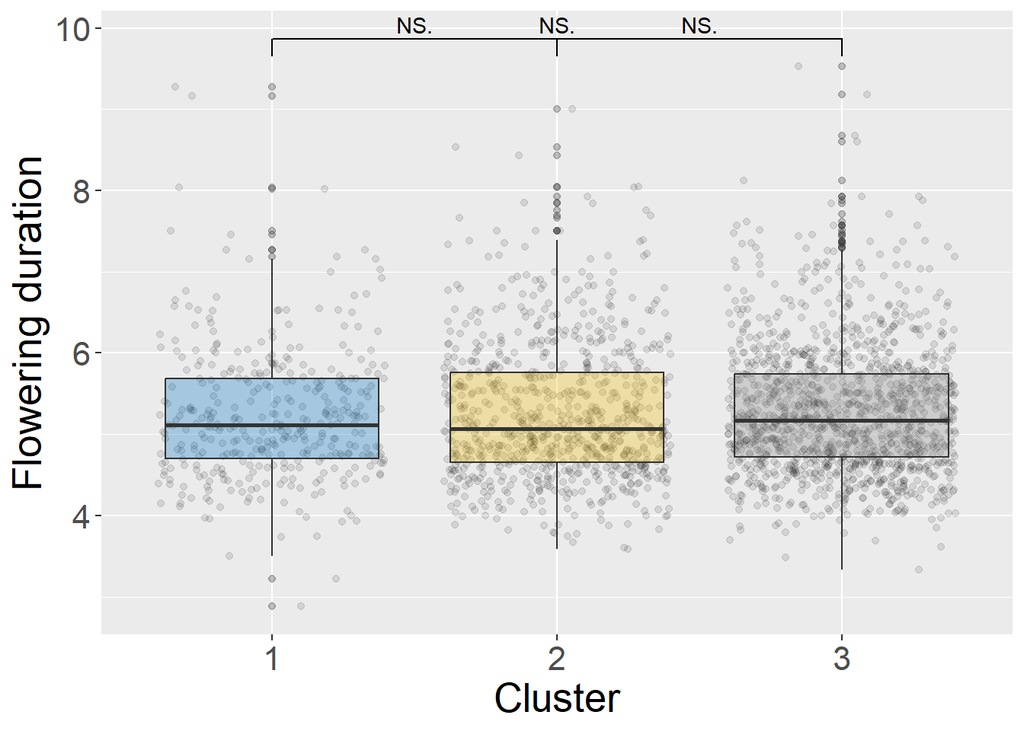

```r
ggplot(data= data_ENI) +
  aes(x= clust, y = Flow_dur,fill=clust) +
  geom_jitter(alpha=0.1)+
  geom_boxplot(alpha=0.3)+
  scale_fill_manual(values=c("#0073C2FF","#EFC000FF","#868686FF"))+
  labs(x="Cluster", y = "Flowering duration")+
  theme(axis.text=element_text(size=16),
        axis.title=element_text(size=20))+
  theme(legend.title = element_text(size=20),
        legend.text = element_text(size=14))+
  geom_signif(comparisons = list(c("1","2"),c("1","3"),c("2","3")),map_signif_level = TRUE)+ theme(legend.position = "none")
```

# 3. Indicateurs botaniques

## 3.1. Richesse spécifique

```r
mod_clust <- aov(rich_sp ~ clust, data=data_ENI)
summary(mod_clust)
```

```
##               Df Sum Sq Mean Sq F value   Pr(>F)
## clust          2   2445  1222.5   22.36 2.39e-10 ***
## Residuals   2407 131593    54.7
## ---
## Signif. codes:  0 '***' 0.001 '**' 0.01 '*' 0.05 '.' 0.1 ' ' 1
```

```r
pairwise.t.test(data_ENI$rich_sp, data_ENI$clust, p.adj = "bonferroni")
```

```
##
##  Pairwise comparisons using t tests with pooled SD
##
## data:  data_ENI$rich_sp and data_ENI$clust
##
##   1       2
## 2 0.00016 -
## 3 1.00000 1.9e-10
##
## P value adjustment method: bonferroni
```

1 et 2 diff 2 et 3 diff 1 et 3 pas diff

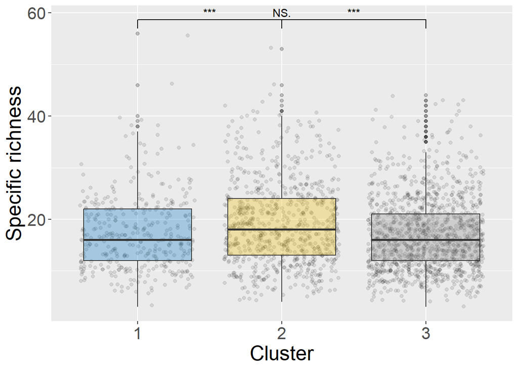

```r
ggplot(data= data_ENI) +
  aes(x= clust, y = rich_sp,fill=clust) +
  geom_jitter(alpha=0.1)+
  geom_boxplot(alpha=0.3)+
  scale_fill_manual(values=c("#0073C2FF","#EFC000FF","#868686FF"))+
  labs(x="Cluster", y = "Specific richness")+
  theme(axis.text=element_text(size=16),
        axis.title=element_text(size=20))+
  theme(legend.title = element_text(size=20),
        legend.text = element_text(size=14))+
  geom_signif(comparisons = list(c("1","2"),c("1","3"),c("2","3")),map_signif_level = TRUE)+ theme(legend.position = "none")
```

## 3.2. Richesse fonctionnelle

```r
mod_clust <- aov(FRic ~ clust, data=data_ENI)
summary(mod_clust)
```

```
##               Df Sum Sq  Mean Sq F value Pr(>F)
## clust          2  0.008 0.003833   2.381 0.0927 .
## Residuals   2395  3.856 0.001610
## ---
## Signif. codes:  0 '***' 0.001 '**' 0.01 '*' 0.05 '.' 0.1 ' ' 1
## 12 observations effacées parce que manquantes
```

```r
pairwise.t.test(data_ENI$FRic, data_ENI$clust, p.adj = "bonferroni")
```

```
##
##  Pairwise comparisons using t tests with pooled SD
##
## data:  data_ENI$FRic and data_ENI$clust
##
##   1    2
## 2 1.00 -
## 3 0.15 0.40
##
## P value adjustment method: bonferroni
```

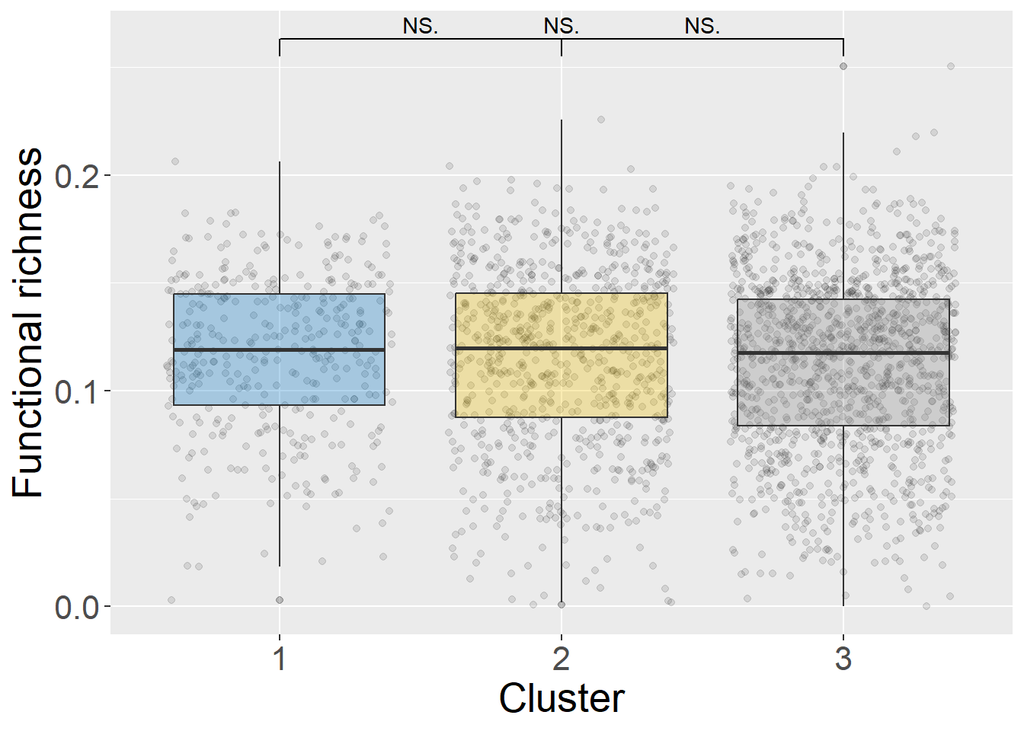

```r
ggplot(data= data_ENI) +
  aes(x= clust, y = FRic,fill=clust) +
  geom_jitter(alpha=0.1)+
  geom_boxplot(alpha=0.3)+
  scale_fill_manual(values=c("#0073C2FF","#EFC000FF","#868686FF"))+
  labs(x="Cluster", y = "Functional richness")+
  theme(axis.text=element_text(size=16),
        axis.title=element_text(size=20))+
  theme(legend.title = element_text(size=20),
        legend.text = element_text(size=14))+
  geom_signif(comparisons = list(c("1","2"),c("1","3"),c("2","3")),map_signif_level = TRUE)+ theme(legend.position = "none")
```

## 3.3. Shannon

```r
mod_clust <- aov(shannon ~ clust, data=data_ENI)
summary(mod_clust)
```

```
##               Df Sum Sq Mean Sq F value   Pr(>F)
## clust          2   0.59  0.2971   12.91 2.64e-06 ***
## Residuals   2407  55.36  0.0230
## ---
## Signif. codes:  0 '***' 0.001 '**' 0.01 '*' 0.05 '.' 0.1 ' ' 1
```

```r
pairwise.t.test(data_ENI$shannon, data_ENI$clust, p.adj = "bonferroni")
```

```
##
##  Pairwise comparisons using t tests with pooled SD
##
## data:  data_ENI$shannon and data_ENI$clust
##
##   1       2
## 2 1.00000 -
## 3 0.00015 0.00012
##
## P value adjustment method: bonferroni
```

1 et 2 pas diff 2 et 3 diff 1 et 3 diff

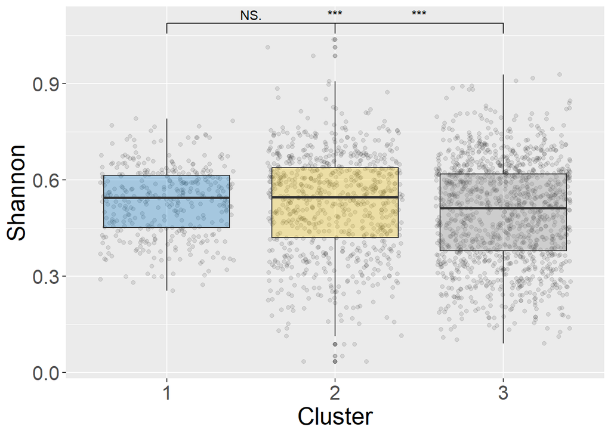

```r
ggplot(data= data_ENI) +
  aes(x= clust, y = shannon,fill=clust) +
  geom_jitter(alpha=0.1)+
  geom_boxplot(alpha=0.3)+
  scale_fill_manual(values=c("#0073C2FF","#EFC000FF","#868686FF"))+
  labs(x="Cluster", y = "Shannon")+
  theme(axis.text=element_text(size=16),
        axis.title=element_text(size=20))+
  theme(legend.title = element_text(size=20),
        legend.text = element_text(size=14))+
  geom_signif(comparisons = list(c("1","2"),c("1","3"),c("2","3")),map_signif_level = TRUE)+ theme(legend.position = "none")
```

## 3.4. % forbs

```r
mod_clust <- aov(forbs_100 ~ clust, data=data_ENI)
summary(mod_clust)
```

```
##               Df Sum Sq Mean Sq F value Pr(>F)
## clust          2  44485   22242   83.18 <2e-16 ***
## Residuals   2407 643627     267
## ---
## Signif. codes:  0 '***' 0.001 '**' 0.01 '*' 0.05 '.' 0.1 ' ' 1
```

```r
pairwise.t.test(data_ENI$forbs_100, data_ENI$clust, p.adj = "bonferroni")
```

```
##
##  Pairwise comparisons using t tests with pooled SD
##
## data:  data_ENI$forbs_100 and data_ENI$clust
##
##   1      2
## 2 <2e-16 -
## 3 0.37   <2e-16
##
## P value adjustment method: bonferroni
```

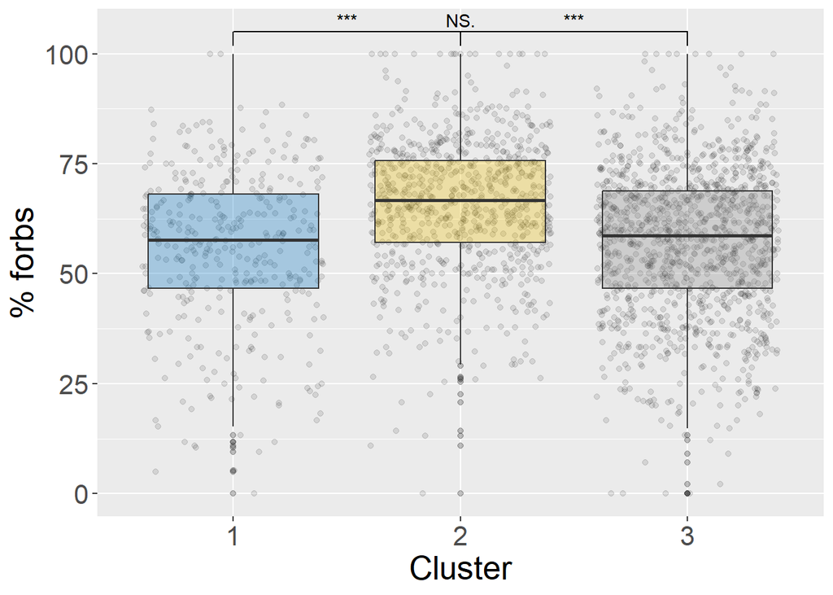

```r
ggplot(data= data_ENI) +
  aes(x= clust, y = forbs_100,fill=clust) +
  geom_jitter(alpha=0.1)+
  geom_boxplot(alpha=0.3)+
  scale_fill_manual(values=c("#0073C2FF","#EFC000FF","#868686FF"))+
  labs(x="Cluster", y = "% forbs")+
  theme(axis.text=element_text(size=16),
        axis.title=element_text(size=20))+
  theme(legend.title = element_text(size=20),
        legend.text = element_text(size=14))+
  geom_signif(comparisons = list(c("1","2"),c("1","3"),c("2","3")),map_signif_level = TRUE)+ theme(legend.position = "none")
```

## 3.5. % nature values species

```r
mod_clust <- aov(nat_val_100 ~ clust, data=data_ENI)
summary(mod_clust)
```

```
##               Df Sum Sq Mean Sq F value Pr(>F)
## clust          2  27724   13862   48.97 <2e-16 ***
## Residuals   2407 681432     283
## ---
## Signif. codes:  0 '***' 0.001 '**' 0.01 '*' 0.05 '.' 0.1 ' ' 1
```

```r
pairwise.t.test(data_ENI$nat_val_100, data_ENI$clust, p.adj = "bonferroni")
```

```
##
##  Pairwise comparisons using t tests with pooled SD
##
## data:  data_ENI$nat_val_100 and data_ENI$clust
##
##   1      2
## 2 3e-16  -
## 3 <2e-16 0.89
##
## P value adjustment method: bonferroni
```

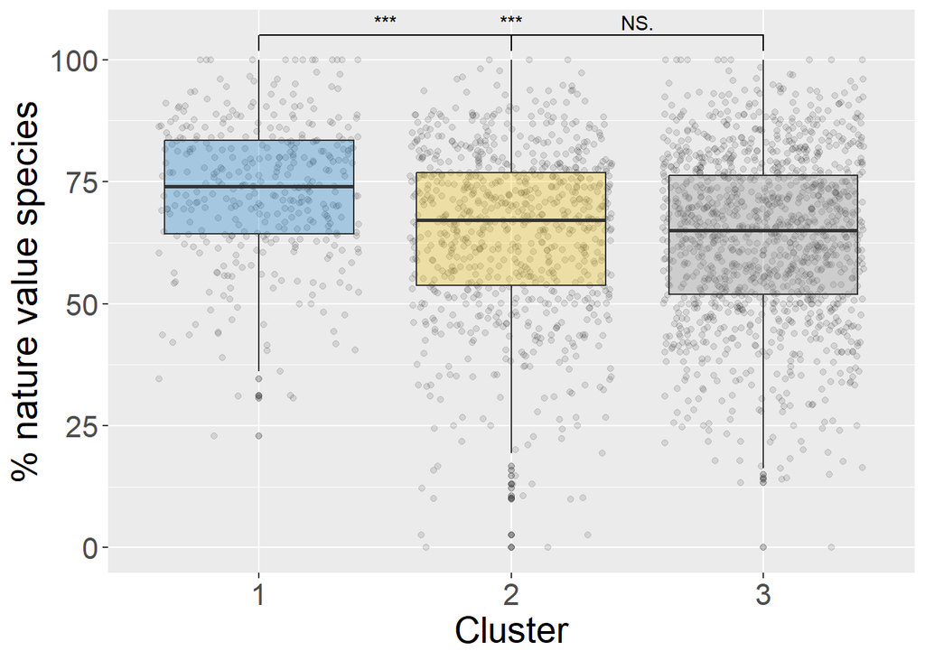

```r
ggplot(data= data_ENI) +
  aes(x= clust, y = nat_val_100,fill=clust) +
  geom_jitter(alpha=0.1)+
  geom_boxplot(alpha=0.3)+
  scale_fill_manual(values=c("#0073C2FF","#EFC000FF","#868686FF"))+
  labs(x="Cluster", y = "% nature value species")+
  theme(axis.text=element_text(size=16),
        axis.title=element_text(size=20))+
  theme(legend.title = element_text(size=20),
        legend.text = element_text(size=14))+
  geom_signif(comparisons = list(c("1","2"),c("1","3"),c("2","3")),map_signif_level = TRUE)+ theme(legend.position = "none")
```

## 3.6. % perennial

```r
mod_clust <- aov(perennial_100 ~ clust, data=data_ENI)
summary(mod_clust)
```

```
##               Df Sum Sq Mean Sq F value Pr(>F)
## clust          2  37707   18854   53.38 <2e-16 ***
## Residuals   2407 850222     353
## ---
## Signif. codes:  0 '***' 0.001 '**' 0.01 '*' 0.05 '.' 0.1 ' ' 1
```

```r
pairwise.t.test(data_ENI$perennial_100, data_ENI$clust, p.adj = "bonferroni")
```

```
##
##  Pairwise comparisons using t tests with pooled SD
##
## data:  data_ENI$perennial_100 and data_ENI$clust
##
##   1       2
## 2 < 2e-16 -
## 3 7.2e-08 1.3e-10
##
## P value adjustment method: bonferroni
```

Tout diff

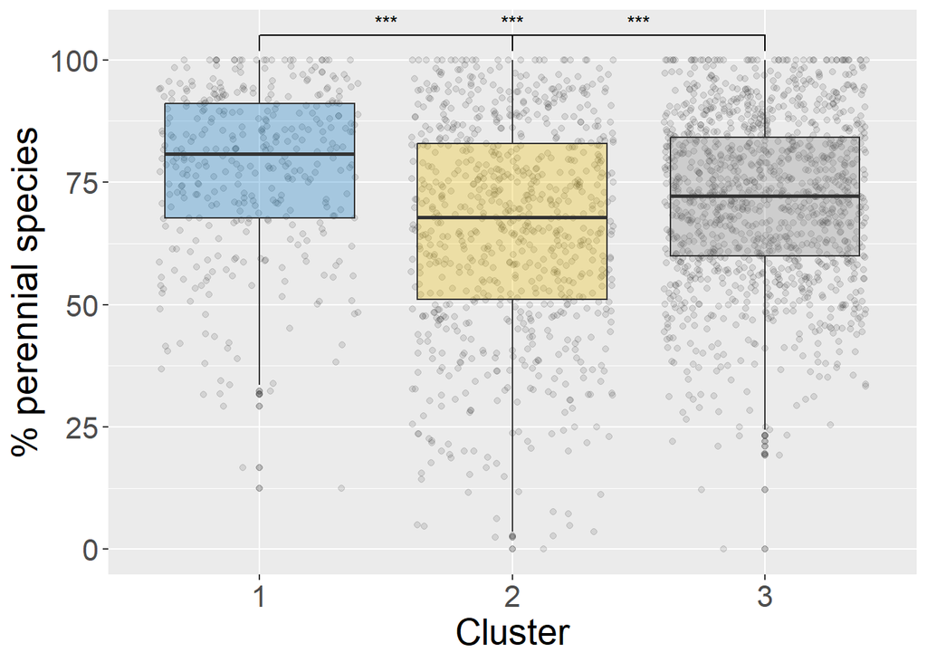

```r
ggplot(data= data_ENI) +
  aes(x= clust, y = perennial_100,fill=clust) +
  geom_jitter(alpha=0.1)+
  geom_boxplot(alpha=0.3)+
  scale_fill_manual(values=c("#0073C2FF","#EFC000FF","#868686FF"))+
  labs(x="Cluster", y = "% perennial species")+
  theme(axis.text=element_text(size=16),
        axis.title=element_text(size=20))+
  theme(legend.title = element_text(size=20),
        legend.text = element_text(size=14))+
  geom_signif(comparisons = list(c("1","2"),c("1","3"),c("2","3")),map_signif_level = TRUE)+ theme(legend.position = "none")
```

## 3.7. % neophytes

```r
mod_clust <- aov(neophytes_100 ~ clust, data=data_ENI)
summary(mod_clust)
```

```
##               Df Sum Sq Mean Sq F value Pr(>F)
## clust          2   1797   898.4   51.67 <2e-16 ***
## Residuals   2407  41850    17.4
## ---
## Signif. codes:  0 '***' 0.001 '**' 0.01 '*' 0.05 '.' 0.1 ' ' 1
```

```r
pairwise.t.test(data_ENI$neophytes_100, data_ENI$clust, p.adj = "bonferroni")
```

```
##
##  Pairwise comparisons using t tests with pooled SD
##
## data:  data_ENI$neophytes_100 and data_ENI$clust
##
##   1       2
## 2 3.8e-13 -
## 3 1       < 2e-16
##
## P value adjustment method: bonferroni
```

1 et 2 diff 2 et 3 diff 1 et 3 pas diff

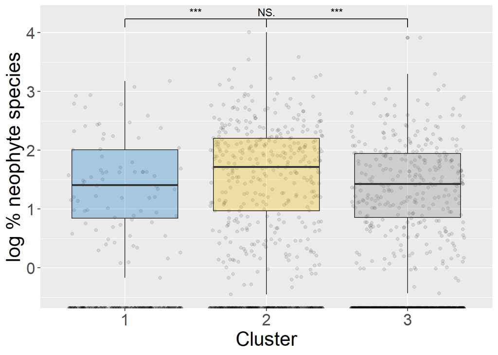

```r
ind_biodiv3 <- data_ENI %>%
  mutate(neophytes_100=log(neophytes_100))

ggplot(data= ind_biodiv3) +
  aes(x= clust, y = neophytes_100,fill=clust) +
  geom_jitter(alpha=0.1)+
  geom_boxplot(alpha=0.3)+
  scale_fill_manual(values=c("#0073C2FF","#EFC000FF","#868686FF"))+
  labs(x="Cluster", y = "log % neophyte species")+
  theme(axis.text=element_text(size=16),
        axis.title=element_text(size=20))+
  theme(legend.title = element_text(size=20),
        legend.text = element_text(size=14))+
  geom_signif(comparisons = list(c("1","2"),c("1","3"),c("2","3")),map_signif_level = TRUE)+ theme(legend.position = "none")
```

# 4. Nectar

```r
mod_clust <- aov(nectar_present_1 ~ clust, data=data_ENI)
summary(mod_clust)
```

```
##               Df Sum Sq Mean Sq F value Pr(>F)
## clust          2   3.95  1.9730   77.83 <2e-16 ***
## Residuals   2407  61.01  0.0253
## ---
## Signif. codes:  0 '***' 0.001 '**' 0.01 '*' 0.05 '.' 0.1 ' ' 1
```

```r
pairwise.t.test(data_ENI$nectar_present_1, data_ENI$clust, p.adj = "bonferroni")
```

```
##
##  Pairwise comparisons using t tests with pooled SD
##
## data:  data_ENI$nectar_present_1 and data_ENI$clust
##
##   1      2
## 2 <2e-16 -
## 3 0.013  <2e-16
##
## P value adjustment method: bonferroni
```

Tous diff

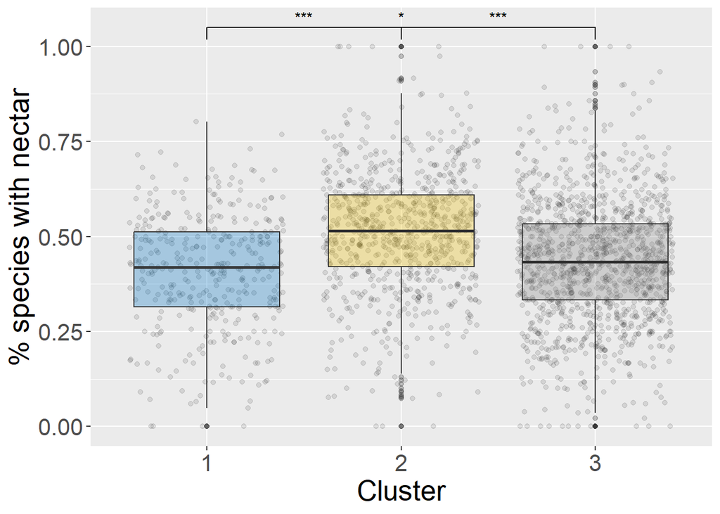

```r
ggplot(data= data_ENI) +
  aes(x= clust, y = nectar_present_1,fill=clust) +
  geom_jitter(alpha=0.1)+
  geom_boxplot(alpha=0.3)+
  scale_fill_manual(values=c("#0073C2FF","#EFC000FF","#868686FF"))+
  labs(x="Cluster", y = "% species with nectar")+
  theme(axis.text=element_text(size=16),
        axis.title=element_text(size=20))+
  theme(legend.title = element_text(size=20),
        legend.text = element_text(size=14))+
  geom_signif(comparisons = list(c("1","2"),c("1","3"),c("2","3")),map_signif_level = TRUE)+ theme(legend.position = "none")
```

# 5. Zygomorphes

## 5.1. Par clusters

```r
mod_clust <- aov(zygomorphe_1 ~ clust, data=data_ENI)
summary(mod_clust)
```

```
##               Df Sum Sq Mean Sq F value Pr(>F)
## clust          2  0.704  0.3519   37.69 <2e-16 ***
## Residuals   2407 22.471  0.0093
## ---
## Signif. codes:  0 '***' 0.001 '**' 0.01 '*' 0.05 '.' 0.1 ' ' 1
```

```r
pairwise.t.test(data_ENI$zygomorphe_1, data_ENI$clust, p.adj = "bonferroni")
```

```
##
##  Pairwise comparisons using t tests with pooled SD
##
## data:  data_ENI$zygomorphe_1 and data_ENI$clust
##
##   1       2
## 2 7.8e-05 -
## 3 0.087   < 2e-16
##
## P value adjustment method: bonferroni
```

Tous diff (tendance pour 1 et 3)

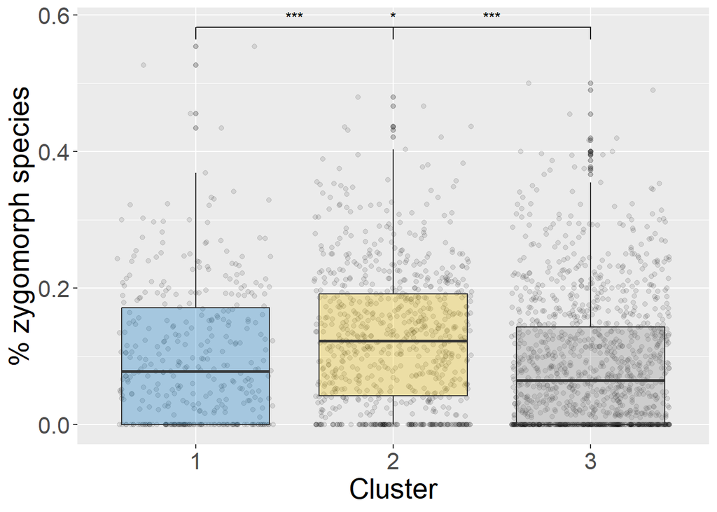

```r
ggplot(data= data_ENI) +
  aes(x= clust, y = zygomorphe_1,fill=clust) +
  geom_jitter(alpha=0.1)+
  geom_boxplot(alpha=0.3)+
  scale_fill_manual(values=c("#0073C2FF","#EFC000FF","#868686FF"))+
  labs(x="Cluster", y = "% zygomorph species")+
  theme(axis.text=element_text(size=16),
        axis.title=element_text(size=20))+
  theme(legend.title = element_text(size=20),
        legend.text = element_text(size=14))+
  geom_signif(comparisons = list(c("1","2"),c("1","3"),c("2","3")),map_signif_level = TRUE)+ theme(legend.position = "none")
```

## 5.2. Par cultures

```r
mod_clust <- aov(zygomorphe_1 ~ TypeCulture, data=data_ENI)
summary(mod_clust)
```

```
##               Df Sum Sq Mean Sq F value Pr(>F)
## TypeCulture    2  2.724  1.3622   160.3 <2e-16 ***
## Residuals   2407 20.450  0.0085
## ---
## Signif. codes:  0 '***' 0.001 '**' 0.01 '*' 0.05 '.' 0.1 ' ' 1
```

```r
pairwise.t.test(data_ENI$zygomorphe_1, data_ENI$TypeCulture, p.adj = "bonferroni")
```

```
##
##  Pairwise comparisons using t tests with pooled SD
##
## data:  data_ENI$zygomorphe_1 and data_ENI$TypeCulture
##
##            GrandesCultures Maraichage
## Maraichage 0.017           -
## Vigne      <2e-16          <2e-16
##
## P value adjustment method: bonferroni
```

Tous diff

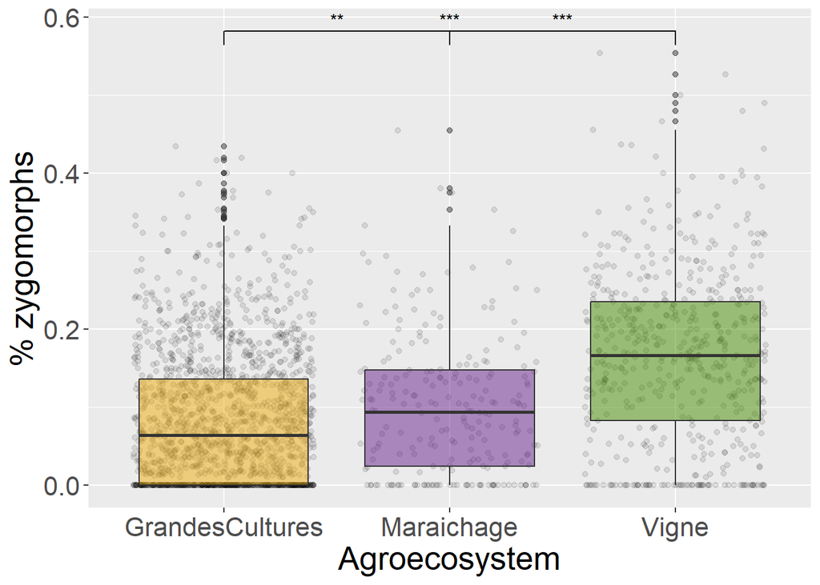

```r
ggplot(data= data_ENI) +
  aes(x= TypeCulture, y = zygomorphe_1,fill=TypeCulture) +
  geom_jitter(alpha=0.1)+
  geom_boxplot(alpha=0.5)+
  scale_fill_manual(values=c("darkgoldenrod2","darkorchid4","#458B00"))+
  labs(x="Agroecosystem", y = "% zygomorphs")+
  theme(axis.text=element_text(size=16),
        axis.title=element_text(size=20))+
  theme(legend.title = element_text(size=20),
        legend.text = element_text(size=14))+
  geom_signif(comparisons = list(c("GrandesCultures","Maraichage"),c("GrandesCultures","Vigne"),c("Maraichage","Vigne")),map_signif_level = TRUE)+ theme(legend.position = "none")
```

# 6. IFTs

## 6.1. Par cultures

```r
mod <- aov(IFT_Herbicide2013_2019 ~ TypeCulture, data=data_ENI)
summary(mod)
```

```
##               Df Sum Sq Mean Sq F value Pr(>F)
## TypeCulture    2    700   350.0     271 <2e-16 ***
## Residuals   2407   3109     1.3
## ---
## Signif. codes:  0 '***' 0.001 '**' 0.01 '*' 0.05 '.' 0.1 ' ' 1
```

```r
pairwise.t.test(data_ENI$IFT_Herbicide2013_2019, data_ENI$TypeCulture, p.adj = "bonferroni")
```

```
##
##  Pairwise comparisons using t tests with pooled SD
##
## data:  data_ENI$IFT_Herbicide2013_2019 and data_ENI$TypeCulture
##
##            GrandesCultures Maraichage
## Maraichage <2e-16          -
## Vigne      <2e-16          0.0011
##
## P value adjustment method: bonferroni
```

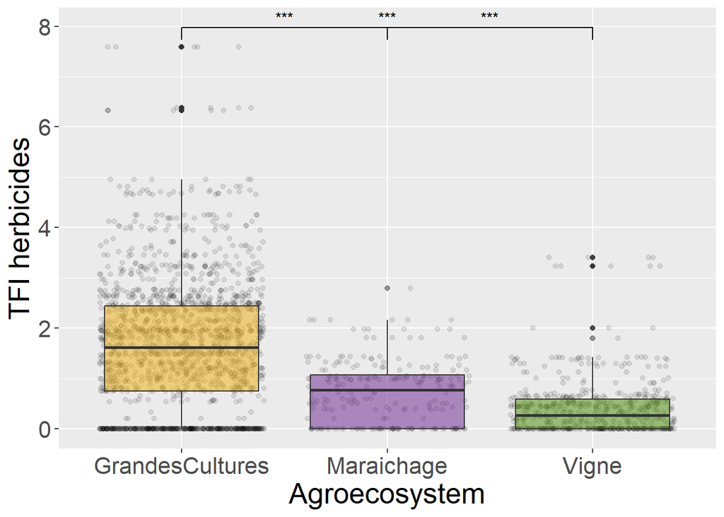

```r
ggplot(data= data_ENI) +
  aes(x= TypeCulture, y = IFT_Herbicide2013_2019,fill=TypeCulture) +
  geom_jitter(alpha=0.1)+
  geom_boxplot(alpha=0.5)+
  scale_fill_manual(values=c("darkgoldenrod2","darkorchid4","#458B00"))+
  labs(x="Agroecosystem", y = "TFI herbicides")+
  theme(axis.text=element_text(size=16),
        axis.title=element_text(size=20))+
  theme(legend.title = element_text(size=20),
        legend.text = element_text(size=14))+
  geom_signif(comparisons = list(c("GrandesCultures","Maraichage"),c("GrandesCultures","Vigne"),c("Maraichage","Vigne")),map_signif_level = TRUE)+ theme(legend.position = "none")
```

## 6.2. Par régions

```r
mod <- aov(IFT_Herbicide2013_2019 ~ region_biogeo, data=data_ENI)
summary(mod)
```

```
##                 Df Sum Sq Mean Sq F value Pr(>F)
## region_biogeo    9    252  27.950   18.86 <2e-16 ***
## Residuals     2400   3557   1.482
## ---
## Signif. codes:  0 '***' 0.001 '**' 0.01 '*' 0.05 '.' 0.1 ' ' 1
```

```r
pairwise.t.test(data_ENI$IFT_Herbicide2013_2019, data_ENI$region_biogeo, p.adj = "bonferroni")
```

```
##
##  Pairwise comparisons using t tests with pooled SD
##
## data:  data_ENI$IFT_Herbicide2013_2019 and data_ENI$region_biogeo
##
##      MC      BRSJ    ZM      A       ZNE     MA      BPS     C       BPN
## BRSJ 1.00000 -       -       -       -       -       -       -       -
## ZM   0.00037 0.00021 -       -       -       -       -       -       -
## A    0.04962 0.03298 1.00000 -       -       -       -       -       -
## ZNE  1.00000 1.00000 1.1e-06 0.03764 -       -       -       -       -
## MA   1.00000 1.00000 4.9e-10 0.00246 1.00000 -       -       -       -
## BPS  0.03400 0.20891 < 2e-16 0.00012 0.00011 1.00000 -       -       -
## C    6.9e-06 3.8e-06 0.25245 1.00000 1.1e-06 6.0e-09 3.2e-12 -       -
## BPN  0.49507 1.00000 1.9e-13 0.00050 0.03305 1.00000 1.00000 1.6e-10 -
## ZSO  1.00000 1.00000 0.00090 0.19665 1.00000 0.00509 5.4e-10 4.4e-05 1.7e-05
##
## P value adjustment method: bonferroni
```

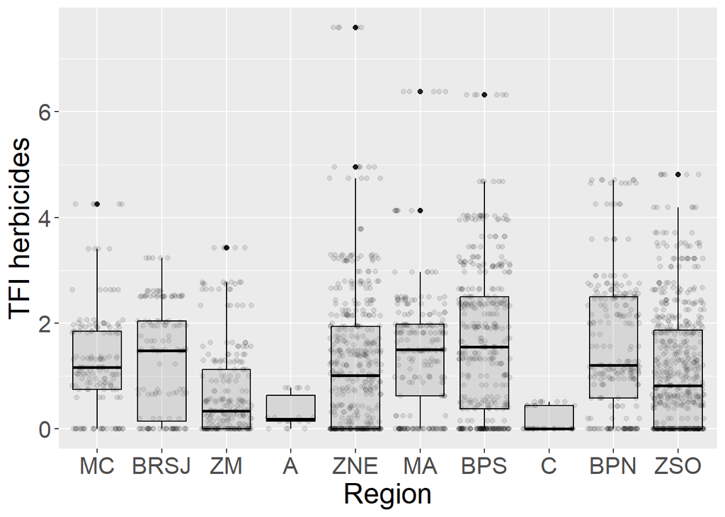

```r
ggplot(data= data_ENI) +
  aes(x= region_biogeo, y = IFT_Herbicide2013_2019) +
  geom_jitter(alpha=0.1)+
  geom_boxplot(alpha=0.3,fill='#A4A4A4', color = "black")+
  labs(x="Region", y = "TFI herbicides")+
  theme(axis.text=element_text(size=16),
        axis.title=element_text(size=20))+
  theme(legend.title = element_text(size=20),
        legend.text = element_text(size=14))+
  theme(legend.position = "none")
```

## 6.3. Par clusters

#### 6.3.1. Herbicides

```r
mod <- aov(IFT_Herbicide2013_2019 ~ clust, data=data_ENI)
summary(mod)
```

```
##               Df Sum Sq Mean Sq F value Pr(>F)
## clust          2    469  234.55     169 <2e-16 ***
## Residuals   2407   3340    1.39
## ---
## Signif. codes:  0 '***' 0.001 '**' 0.01 '*' 0.05 '.' 0.1 ' ' 1
```

```r
pairwise.t.test(data_ENI$IFT_Herbicide2013_2019, data_ENI$clust, p.adj = "bonferroni")
```

```
##
##  Pairwise comparisons using t tests with pooled SD
##
## data:  data_ENI$IFT_Herbicide2013_2019 and data_ENI$clust
##
##   1       2
## 2 1.8e-07 -
## 3 1.4e-15 < 2e-16
##
## P value adjustment method: bonferroni
```

tous diff

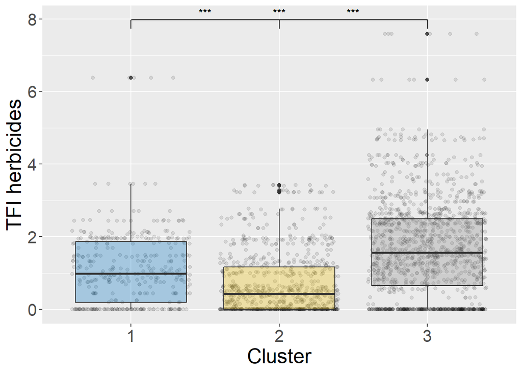

```r
ggplot(data= data_ENI) +
  aes(x= clust, y = IFT_Herbicide2013_2019,fill=clust) +
  geom_jitter(alpha=0.1)+
  geom_boxplot(alpha=0.3)+
  scale_fill_manual(values=c("#0073C2FF","#EFC000FF","#868686FF"))+
  labs(x="Cluster", y = "TFI herbicides")+
  theme(axis.text=element_text(size=16),
        axis.title=element_text(size=20))+
  theme(legend.title = element_text(size=20),
        legend.text = element_text(size=14))+
  geom_signif(comparisons = list(c("1","2"),c("1","3"),c("2","3")),map_signif_level = TRUE)+ theme(legend.position = "none")
```

#### 6.3.2. Hors herbicides

```r
mod <- aov(IFT_Hors_Herbicide2013_2019 ~ clust, data=data_ENI)
summary(mod)
```

```
##               Df Sum Sq Mean Sq F value Pr(>F)
## clust          2   1625   812.3   58.96 <2e-16 ***
## Residuals   2407  33160    13.8
## ---
## Signif. codes:  0 '***' 0.001 '**' 0.01 '*' 0.05 '.' 0.1 ' ' 1
```

```r
pairwise.t.test(data_ENI$IFT_Hors_Herbicide2013_2019, data_ENI$clust, p.adj = "bonferroni")
```

```
##
##  Pairwise comparisons using t tests with pooled SD
##
## data:  data_ENI$IFT_Hors_Herbicide2013_2019 and data_ENI$clust
##
##   1       2
## 2 4.2e-12 -
## 3 1       < 2e-16
##
## P value adjustment method: bonferroni
```

1 et 2 diff 2 et 3 diff 1 et 3 pas diff

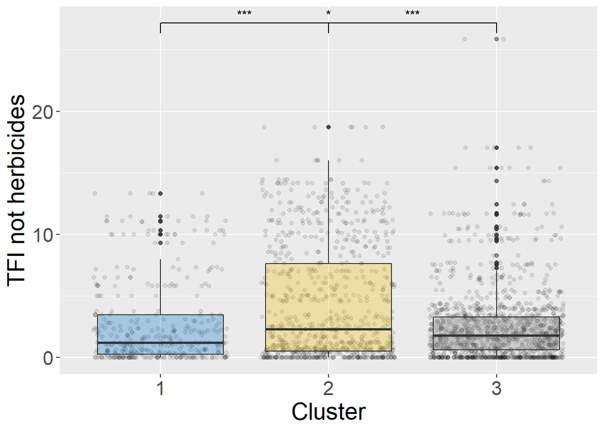

```r
ggplot(data= data_ENI) +
  aes(x= clust, y = IFT_Hors_Herbicide2013_2019,fill=clust) +
  geom_jitter(alpha=0.1)+
  geom_boxplot(alpha=0.3)+
  scale_fill_manual(values=c("#0073C2FF","#EFC000FF","#868686FF"))+
  labs(x="Cluster", y = "TFI not herbicides")+
  theme(axis.text=element_text(size=16),
        axis.title=element_text(size=20))+
  theme(legend.title = element_text(size=20),
        legend.text = element_text(size=14))+
  geom_signif(comparisons = list(c("1","2"),c("1","3"),c("2","3")),map_signif_level = TRUE)+ theme(legend.position = "none")
```

# 7. Autres pratiques

```r
mod <- aov(CoefN ~ clust, data=data_ENI)
summary(mod)
```

```
##               Df  Sum Sq Mean Sq F value Pr(>F)
## clust          2 1610421  805211   226.2 <2e-16 ***
## Residuals   2407 8566778    3559
## ---
## Signif. codes:  0 '***' 0.001 '**' 0.01 '*' 0.05 '.' 0.1 ' ' 1
```

```r
pairwise.t.test(data_ENI$IFT_Hors_Herbicide2013_2019, data_ENI$clust, p.adj = "bonferroni")
```

```
##
##  Pairwise comparisons using t tests with pooled SD
##
## data:  data_ENI$IFT_Hors_Herbicide2013_2019 and data_ENI$clust
##
##   1       2
## 2 4.2e-12 -
## 3 1       < 2e-16
##
## P value adjustment method: bonferroni
```

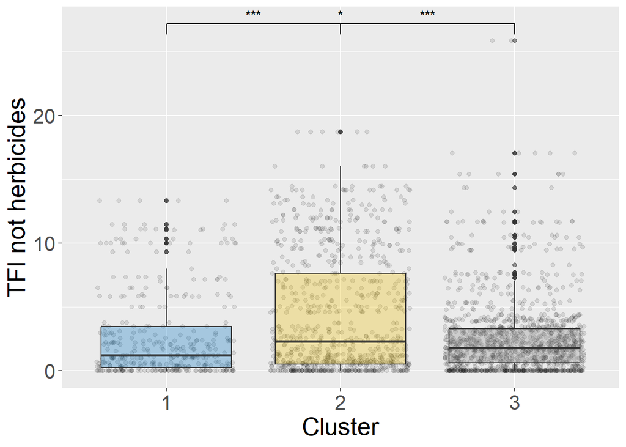

```r
ggplot(data= data_ENI) +
  aes(x= clust, y = IFT_Hors_Herbicide2013_2019,fill=clust) +
  geom_jitter(alpha=0.1)+
  geom_boxplot(alpha=0.3)+
  scale_fill_manual(values=c("#0073C2FF","#EFC000FF","#868686FF"))+
  labs(x="Cluster", y = "TFI not herbicides")+
  theme(axis.text=element_text(size=16),
        axis.title=element_text(size=20))+
  theme(legend.title = element_text(size=20),
        legend.text = element_text(size=14))+
  geom_signif(comparisons = list(c("1","2"),c("1","3"),c("2","3")),map_signif_level = TRUE)+ theme(legend.position = "none")
```

```r
mod <- aov(IFT_Hors_Herbicide2013_2019 ~ clust, data=data_ENI)
summary(mod)
```

```
##               Df Sum Sq Mean Sq F value Pr(>F)
## clust          2   1625   812.3   58.96 <2e-16 ***
## Residuals   2407  33160    13.8
## ---
## Signif. codes:  0 '***' 0.001 '**' 0.01 '*' 0.05 '.' 0.1 ' ' 1
```

```r
pairwise.t.test(data_ENI$IFT_Hors_Herbicide2013_2019, data_ENI$clust, p.adj = "bonferroni")
```

```
##
##  Pairwise comparisons using t tests with pooled SD
##
## data:  data_ENI$IFT_Hors_Herbicide2013_2019 and data_ENI$clust
##
##   1       2
## 2 4.2e-12 -
## 3 1       < 2e-16
##
## P value adjustment method: bonferroni
```

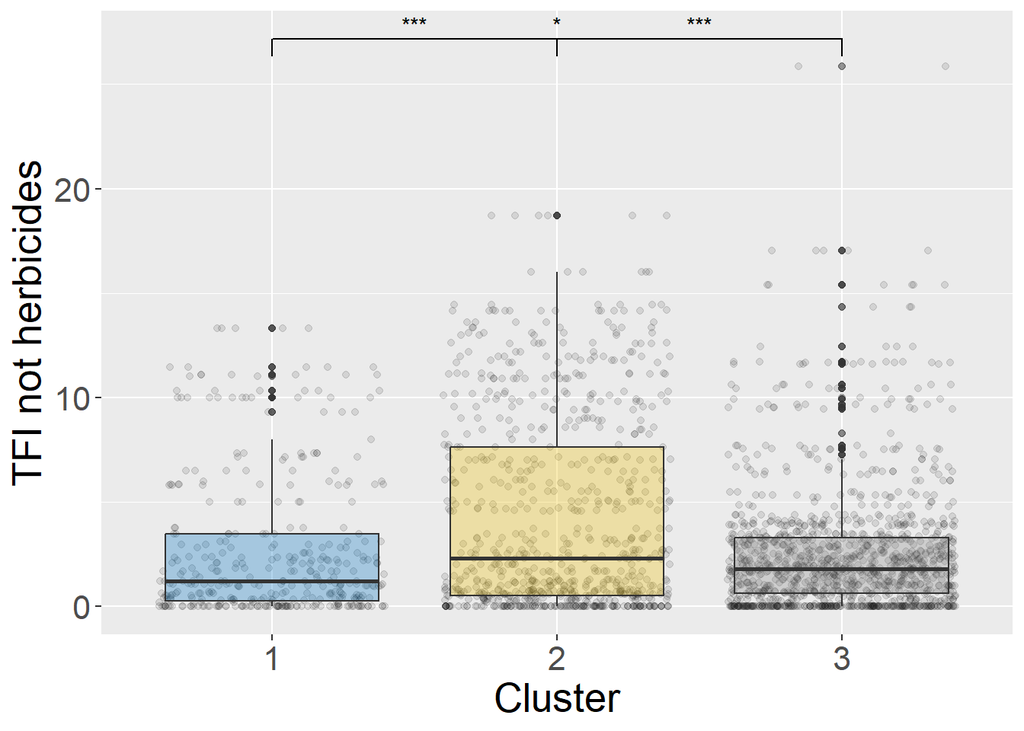

```r
ggplot(data= data_ENI) +
  aes(x= clust, y = IFT_Hors_Herbicide2013_2019,fill=clust) +
  geom_jitter(alpha=0.1)+
  geom_boxplot(alpha=0.3)+
  scale_fill_manual(values=c("#0073C2FF","#EFC000FF","#868686FF"))+
  labs(x="Cluster", y = "TFI not herbicides")+
  theme(axis.text=element_text(size=16),
        axis.title=element_text(size=20))+
  theme(legend.title = element_text(size=20),
        legend.text = element_text(size=14))+
  geom_signif(comparisons = list(c("1","2"),c("1","3"),c("2","3")),map_signif_level = TRUE)+ theme(legend.position = "none")
```

```r
mod <- aov(IFT_Hors_Herbicide2013_2019 ~ clust, data=data_ENI)
summary(mod)
```

```
##               Df Sum Sq Mean Sq F value Pr(>F)
## clust          2   1625   812.3   58.96 <2e-16 ***
## Residuals   2407  33160    13.8
## ---
## Signif. codes:  0 '***' 0.001 '**' 0.01 '*' 0.05 '.' 0.1 ' ' 1
```

```r
pairwise.t.test(data_ENI$IFT_Hors_Herbicide2013_2019, data_ENI$clust, p.adj = "bonferroni")
```

```
##
##  Pairwise comparisons using t tests with pooled SD
##
## data:  data_ENI$IFT_Hors_Herbicide2013_2019 and data_ENI$clust
##
##   1       2
## 2 4.2e-12 -
## 3 1       < 2e-16
##
## P value adjustment method: bonferroni
```

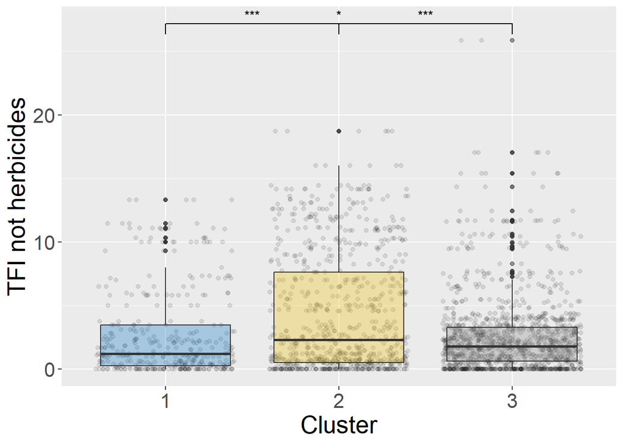

```r
ggplot(data= data_ENI) +
  aes(x= clust, y = IFT_Hors_Herbicide2013_2019,fill=clust) +
  geom_jitter(alpha=0.1)+
  geom_boxplot(alpha=0.3)+
  scale_fill_manual(values=c("#0073C2FF","#EFC000FF","#868686FF"))+
  labs(x="Cluster", y = "TFI not herbicides")+
  theme(axis.text=element_text(size=16),
        axis.title=element_text(size=20))+
  theme(legend.title = element_text(size=20),
        legend.text = element_text(size=14))+
  geom_signif(comparisons = list(c("1","2"),c("1","3"),c("2","3")),map_signif_level = TRUE)+ theme(legend.position = "none")
```